# R Refresher: Notebooks, Notation and Visualization

UC Berkeley Social 273M: Computational Social Science, Part B

March 05, 2024

# Learning Objectives

1. Basic R commands and useful functions in tidyverse
2. Import and manipulate data
3. A note on data.table vs data.frame and dplyr
4. Introduce functions to generate random numbers
5. R markdown
6. Latex symbols and math equations for Casual Inference
7. Review of Notation

# Basic R Commands

R shares many similarities to Python. Both are object oriented programming languages, and thus the same conventions around variable assignment, functions, for loops etc. will be the same. There are differences in terms of syntax, but if you’re comfortable with Python, making the switch over to R will be relatively painless. Both languages complement each other well - Python is well suited to text analysis, computer vision, and software development while R has more options for state-of-the-art causal inference methods. These differences mostly come down to the availability of open source libraries that specialize in these tasks, rather than inherent difference between the languages themselves. Both are increasingly well suited to machine learning generally through the sklearn library in Python and the tidymodels library in R.

Let’s start with variable assignment. Here you’ll notice that this looks basically the same as what we did with Python, but in R it’s more standard to use the carrot “<-” operator to do variable assignment instead of “=”, but both work. We can also check booleans exactly the same way:

```r
# Assignment using <- or =
# ----------
x <- 1
x
```

```
## [1] 1
```

```r
y = 2
y
```

```
## [1] 2
```

```r
# Check equality using ==
# ----------
x == y
```

```
## [1] FALSE
```

```r
x != y
```

```
## [1] TRUE
```

In Python, we mainly worked organized data in dataframes, lists, and dictionaries, and data was usually something like an integer, float, or string. R has similar concepts, but introduces a few new data types that are common as well. In particular, R introduces the notion of a `vector` which is a special data type that contains elements of the same type. We can concatenate a vector by using the `c()` function.

```r
#
# illustrate differences between different object classes
# --------------------------------------------------

# specify different types of vectors
# ----------

pets_vector <- c('dog', 'cat', 'parrot')

pets_list <- list('dog', 'cat', 'parrot')

num_vector <- c(1, 2, 3)

mixed_data <- c(1, 'dog', 2, 'cat')

dog <- 'dog'


# print class of each data type
# ----------
class(pets_vector)
```

```
## [1] "character"
```

```r
class(pets_list)
```

```
## [1] "list"
```

```r
class(num_vector)
```

```
## [1] "numeric"
```

```r
class(mixed_data)
```

```
## [1] "character"
```

```r
class(dog)
```

```
## [1] "character"
```

Notice how when we checked the class of both `pets_vector` and `dog` it returned a character, but a list when we explicitly called list. We got “numeric” with our vector of numbers, but then “character” again when we mixed strings and numbers - R converted these all to characters! Vectors have important consequences for computation because many methods in R are vectorized - meaning they operate on all items in a vector simultaneously. This makes vectorized methods a powerful alternative to for loops. Before we see how this works, let’s see how we construct for loops:

```r
# loop over pet vector
# ----------
for (pet in pets_vector) {
  print(pet)
}
```

```
## [1] "dog"
## [1] "cat"
## [1] "parrot"
```

The syntax is a little different from Python but otherwise looks and feels pretty similar! Now let’s check out the difference between vectorized methods and for loops by finding the log of numbers 1 to 1,000,000.

```r
#
# comparing vector operations and loops 1
# --------------------------------------------------

# create vector of numbers
# ----------
numbers <- 1:1000000

# vectorization
# ----------

# print the log of each number in the vector
print(system.time(numbers_log_vec <- log(numbers)))
```

```
##    user  system elapsed
##   0.003   0.000   0.004
```

```r
# loops
# ----------

# initialize empty list
numbers_for_loop <- list()

# find log by looping over each number
print(system.time(for (number in numbers) {
  numbers_for_loop[number] <- log(number)
}))
```

```
##    user  system elapsed
##   0.915   0.023   0.940
```

```r
# !!! NOTE THESE TIMES WILL VARY ON BASED ON YOUR COMPUTER'S SPECS !!!
```

We’ll introduce two more concepts here to show you the power of vectorization. First, we’ll define a function that takes a number, subtracts 1, and then returns the result. Again, notice the slight differences in syntax between R and Python. Now what if we wanted to “apply” this function to every element in our vector - or say every row in a dataframe? We can use an `apply` method (in this case `sapply` which returns a vector) to apply the function to every element in the vector. Again notice how quickly this goes!

```r
#
# comparing vector operations and loops 2
# --------------------------------------------------

# define a function
# ----------
minus_one <- function(num) {
  nums_minus_one <- num - 1
  return(nums_minus_one)
}

# using vectorization
# ----------
system.time(apply_minus_one <- sapply(numbers, minus_one))
```

```
##    user  system elapsed
##   0.494   0.006   0.501
```

```r
# Using map familiy instead of apply family
# ----------
#install.packages("purrr")
library(purrr)    # functional programming  "purrr" package from Tidyverse

system.time(apply_minus_one <- map_int(numbers, minus_one))
```

```
##    user  system elapsed
##   0.282   0.003   0.285
```

```r
# using a loop -- sapply
# ----------
minus_one_list <- list()
system.time(for (num in numbers) {
  minus_one_list[num] <- minus_one(num)
})
```

```
##    user  system elapsed
##   1.379   0.016   1.396
```

These examples seem straightforward, but vectorization is a powerful concept that makes R a versatile tool for computational social science. Mastering the use of vectors, functions, and apply methods can dramatically speed up your computations.

# Importing and Manipulating Data

Now let’s move to data frames. These work basically the same way they do in Python - we organize data in rows and columns and we can have numbers, characters, and even other dataframes/lists/vectors as values. Here we will import the “strength.csv” data. The dataset contains information on subjects (id) who had one of three exercise treatments (tx). Their strength rating (y) is tracked over time (7 weeks).

Before we start looking at the data though, we’ll need to deal with some issues with how R handles working directories. While Jupyter recognizes your current working directory as the one where your .ipynb notebook lives, R does not do this by default. One way to make this work is to go to Session -> Set Working Directory -> To Source File Location. This is a bit cumbersome and not always reproducible though. Luckily, the `here` library should be able to help us out:

```r
#
# setting working directories
# --------------------------------------------------

# install libraries
# ----------
#install.packages('here')     # might need to install
here::i_am('R Refresher.Rmd') # declare where you are -- "library:function"  allows you to run a function without loading it
```

```
## here() starts at /Users/Dora/git/Computational-Social-Science-Training-Program/6 Causal Inference/6-1 R Refresher
```

```r
library(here)                 # loading the library  - don't use require

# install libraries
# ----------
here()                        # setting working directory as the relative file path
```

```
## [1] "/Users/Dora/git/Computational-Social-Science-Training-Program/6 Causal Inference/6-1 R Refresher"
```

```r
setwd(here())                 # if you work in other environment, you may need to set the working directory this way
```

Now that we have our working directory set, let’s read in our dataframe. In addition to the `head()` function, investigate the output of the names() and dim() functions. Note that this code chunks requires installing the `readr` library. In later scripts we will install a family of libraries called the `tidyverse` in one step instead of having to load them individually. See the documentation on the [tidyverse](https://tidyverse.tidyverse.org) to learn more about what is included.

```r
# installing libraries
# ----------
library(readr)


# load dataa
# ----------
df <- read_csv(here("../../data/strength.csv")) # here() essentially is the working directory
head(df)
```

| id | tx | y | time |
| --- | --- | --- | --- |
| 1 | 1 | 85 | 1 |
| 1 | 1 | 85 | 2 |
| 1 | 1 | 86 | 3 |
| 1 | 1 | 85 | 4 |
| 1 | 1 | 87 | 5 |
| 1 | 1 | 86 | 6 |

```r
names(df)  # shows you the column names
```

```
## [1] "id"   "tx"   "y"    "time"
```

```r
dim(df)
```

```
## [1] 399   4
```

```r
#?read_csv  #check documentation
```

We can also manipulate data using functions from the `tidyverse` library. Check out the [documentation here](https://tidyverse.tidyverse.org). A quick note about the `tidyvere`. R is a relatively old programming language used for statistical analysis but has undergone a revitalization and retooling over the the last 10-15 years. This was largely led by the development of the `tidyverse`, which is a movement to create a consistent and harmonized approach to working with data. Specifically, the goal is for new packages and libraries to use consistent approaches of working with data so that if you come to a new package, you have a general sense of the default settings and how thigns work. This is largely based on the principal of working with tidy (long) data, where each row is an observation and each column in a feature.

It has been widely adopted in the R environment, so much so that it there are two different ways of coding in R: base R, which will look much more like `python`, and the `tidyverse`, which is easier to read and more intuitive. You can [read more about the reasoning and philosophy here](https://rviews.rstudio.com/2017/06/08/what-is-the-tidyverse/). It’s fine not to adopt this approach, but know it is the dominant way of working with data in the open-source R world.

A whole module could be taught on the `tidyverse`, but let’s learn using a few example. First, one example of working with data using the `tidyverse` approach is to add a column using the `mutate()` function. We can select (or deselect) a subset of columns using `select()`. Note that in the example of the select function below there is a negative sign preceding `y_2`, meaning we are selecting everything except `y_2.` The goal of the verbs is to be descriptive in the action that you are taking when you manipulate data.

```r
#
# processing data - adding columns
# --------------------------------------------------


# installing libraries
# ----------
#install.packages("dplyr")

# load library for data manipulation
# ----------
library(dplyr)  # note this would already be loaded if load tidyverse at the beginning

# create new column
# ----------
df <- mutate(df,           # specify data (always the first argument)
             y_2 = y*2)    # note this is equivalent to the base R command: df$y_2 = (df$y)*2

# view - note we can use glimpse() in the future
head(df)  # view first 5 lines
```

| id | tx | y | time | y_2 |
| --- | --- | --- | --- | --- |
| 1 | 1 | 85 | 1 | 170 |
| 1 | 1 | 85 | 2 | 170 |
| 1 | 1 | 86 | 3 | 172 |
| 1 | 1 | 85 | 4 | 170 |
| 1 | 1 | 87 | 5 | 174 |
| 1 | 1 | 86 | 6 | 172 |

```r
# drop columns using the select() function
# ----------
df <- select(df,   # specify data
             -y_2) # select everything but y_2

# view
head(df)
```

| id | tx | y | time |
| --- | --- | --- | --- |
| 1 | 1 | 85 | 1 |
| 1 | 1 | 85 | 2 |
| 1 | 1 | 86 | 3 |
| 1 | 1 | 85 | 4 |
| 1 | 1 | 87 | 5 |
| 1 | 1 | 86 | 6 |

The `tidyverse` also provides the pipe operator, which is the most important implementation that the `tidyverse` uses that makes it so easy to use. This operator (%>%) can be used to pass the output from one function to another, such as when you are performing a series of operations. This is probably the most powerful and intuitive functionality provided by the `tidyverse` - basically the output of the last step becomes the input to the next step.

```r
# piping
# ----------
tidy_df <-
  df %>%
  # rename a variable
  rename(treatment = tx) %>%
  # mutate
  mutate(rescale_y = y * 1000)

# view
head(tidy_df)
```

| id | treatment | y | time | rescale_y |
| --- | --- | --- | --- | --- |
| 1 | 1 | 85 | 1 | 85000 |
| 1 | 1 | 85 | 2 | 85000 |
| 1 | 1 | 86 | 3 | 86000 |
| 1 | 1 | 85 | 4 | 85000 |
| 1 | 1 | 87 | 5 | 87000 |
| 1 | 1 | 86 | 6 | 86000 |

The filter() function is used to select a subset of rows.

```r
# filtering
# ----------
df_id1 <-              # save what the following steps as this object name
  df %>%               # pipe the dataframe instead, following L --> R flow
  filter(id == 1) %>%  # filter only where ID == 1
  glimpse()            # glimpse previews the dataframe
```

```
## Rows: 7
## Columns: 4
## $ id   <dbl> 1, 1, 1, 1, 1, 1, 1
## $ tx   <dbl> 1, 1, 1, 1, 1, 1, 1
## $ y    <dbl> 85, 85, 86, 85, 87, 86, NA
## $ time <dbl> 1, 2, 3, 4, 5, 6, 7
```

```r
dim(df_id1) # returns dimensions of dataframe
```

```
## [1] 7 4
```

```r
# Note: to achieve the same result in base R we could do:
# df_id1 <- df[df$id == 1, ]

# using an "," or "&" statement to filter on more than one condition
df %>%
  filter(id == 1,
         time == 1) %>%
  glimpse()
```

```
## Rows: 1
## Columns: 4
## $ id   <dbl> 1
## $ tx   <dbl> 1
## $ y    <dbl> 85
## $ time <dbl> 1
```

```r
# using an OR statement
filter(df, time == 1 | time == 7)
```

| id | tx | y | time |
| --- | --- | --- | --- |
| 1 | 1 | 85 | 1 |
| 1 | 1 | NA | 7 |
| 2 | 1 | 80 | 1 |
| 2 | 1 | NA | 7 |
| 3 | 1 | 78 | 1 |
| 3 | 1 | 77 | 7 |
| 4 | 1 | 84 | 1 |
| 4 | 1 | 85 | 7 |
| 5 | 1 | 80 | 1 |
| 5 | 1 | 80 | 7 |

[output cut: 104 more lines]

We can also summarize data within groups using the group_by() and summarize() functions.

```r
# summarizing
# ----------
tidy_df %>%
  group_by(time) %>%  # group by to perform calculations by the grouping variable
  summarize(mean_strength = mean(y, na.rm=TRUE),
            standard_deviation_y = sd(y, na.rm=TRUE))
```

| time | mean_strength | standard_deviation_y |
| --- | --- | --- |
| 1 | 80.21053 | 2.980513 |
| 2 | 80.78571 | 3.131739 |
| 3 | 80.94545 | 3.363300 |
| 4 | 81.35714 | 3.199026 |
| 5 | 81.16981 | 3.598802 |
| 6 | 80.95745 | 3.419620 |
| 7 | 80.93478 | 3.647844 |

## Challenge 1

Find the average strength at the last time point in each group (hint, use filter, group_by and summarize).

```r
# find the average strength by group at last point in time
# ----------
tidy_df %>%
  # filter
  filter(time == 7) %>%
  # group by
  group_by(treatment) %>%
    # summarize
    summarize(mean_strength = mean(y, na.rm=TRUE))
```

| treatment | mean_strength |
| --- | --- |
| 1 | 79.31250 |
| 2 | 81.06667 |
| 3 | 82.53333 |

# A note on data.table vs data.frame and dplyr

The [`data.table` package](https://rdatatable.gitlab.io/data.table/) is a package that is useful for manipulating large datasets. You can store data as a *data.table* object, manipulate it using syntax similar to base R syntax, and using additional functions including *subset*, and read/write functions like *fread* and *fwrite*. The *data.table* objects are more-or-less enhanced *data.frame* objects that use different and more efficent underlying code to enable calculations to run faster.

`dplyr` is a package in the `tidyverse` collection of packages that uses functions emphasized in labs 1-3, such as *filter*, *select*, and *rename*. The functions in `dplyr` are really useful for operating on data stored in *data.frame* objects, but can’t be used to manipulate `data.table` objects.

Until recently, however. The new `dtplyr` package was developed to allow you to use tidyverse consistent code on data.table objects. Here is [blog post](https://www.tidyverse.org/blog/2019/11/dtplyr-1-0-0/) explaining how this works. Essentially, convert the data.table object to lazy dataframe (using the `lazy_dt()`), which records all the manipulations you want to do to the dataset, and then translates those manipulations under the hood to data.frame object.

# Generating Random Numbers

Sometimes we want to generate random numbers from probability distributions. This will be useful later when we assess the performance of estimators on a sample from a known data-generating process.

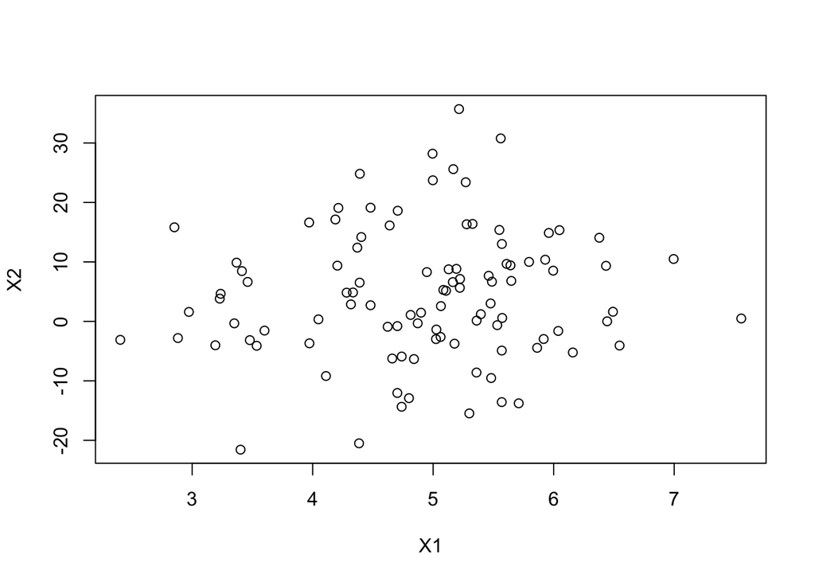

```r
#
# processing data - adding columns
# --------------------------------------------------

# set seed for reproducibility
set.seed(1921)

# X1 and X2 are independently generated normal random variables
# ----------
X1 <- rnorm(n = 100, mean = 5, sd = 1)
X2 <- rnorm(n = 100, mean = 5, sd = 10)

# plot to show they do not appear to be related
plot(x = X1, y = X2)
```

```r
cor(X1, X2)
```

```
## [1] 0.08589659
```

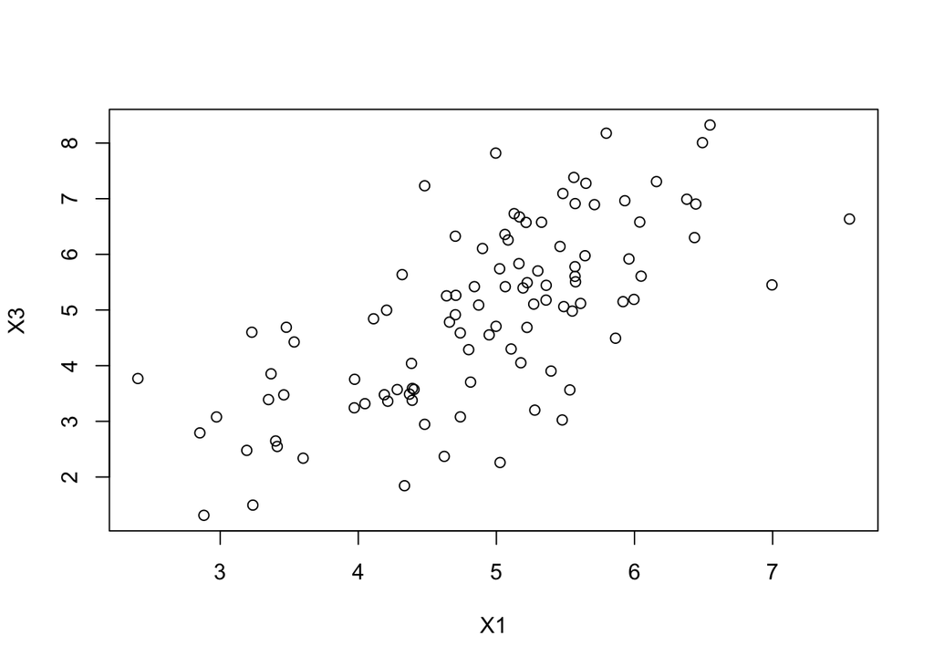

```r
# Here X3 depends on X1
# ----------
X3 <- rnorm(n = 100, mean = X1, sd = 1)

# plot to show they appear to be associated
plot(x = X1, y = X3)
```

```r
cor(X1, X3)
```

```
## [1] 0.684406
```

```r
# combine these three random variables together in a dataframe
# ----------
rand_nums <- tibble(X1, X2, X3) # tibble is tidyverse dataframe
head(rand_nums)
```

| X1 | X2 | X3 |
| --- | --- | --- |
| 5.476778 | 3.017071 | 3.024798 |
| 3.970754 | 16.627272 | 3.242834 |
| 4.738947 | -5.903305 | 3.080332 |
| 6.492004 | 1.621118 | 8.006635 |
| 5.929940 | 10.372691 | 6.963499 |
| 4.213552 | 19.077910 | 3.361292 |

```r
# We could now work with these randomly generated numbers in this data frame, e.g., to fit a model or estimate a parameter of interest (later).
```

# ggplot

Aside from `dplyr` and `tidyr`, another pillar of the tidyverse is `ggplot.` R has base plotting functions that are good for visualizing data quickly (as we saw above), but ggplot offers a of more customization and aesthetically pleasing options.

However, the base syntax takes a bit of getting used to. It follows the [grammar of graphics logic](https://ggplot2.tidyverse.org) where you provide data and tell it how to map those variables to aesthetics. Specifically, instead of using the “%>%” you use the “+” add different layers to the plot. While it takes a bit of getting used to, it is a powerful framework for making figures or even maps.

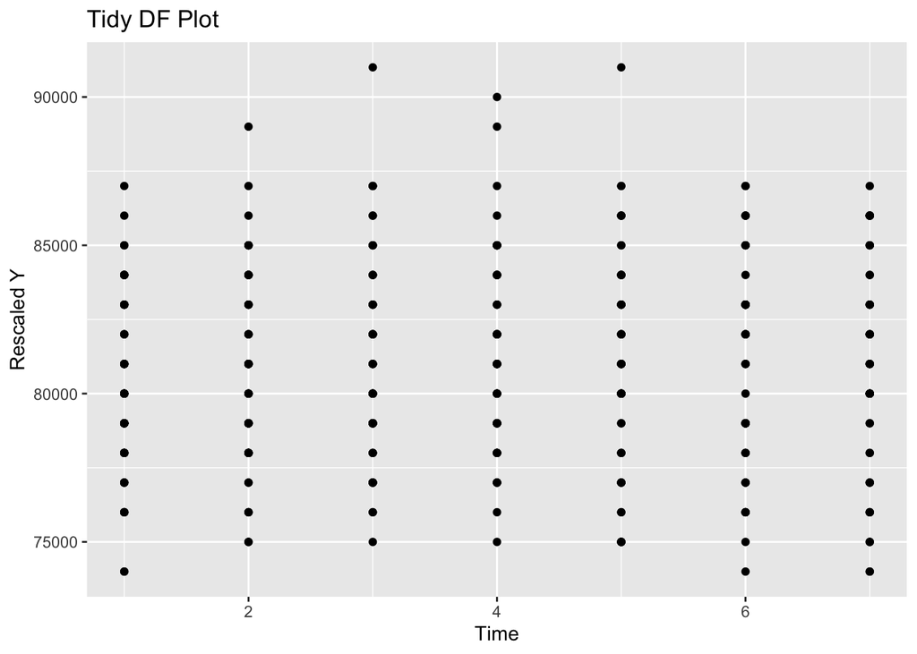

```r
# library loads in tidyverse
#library(ggplot2)

# create a figure
# ----------
tidy_df %>%  # pipe the data into the ggplot

  # initialize a ggplot object -- WILL NEED TO DO THIS WHENEVER YOU WANT TO APPLY GGPLOT
  ggplot() +
  # specify the geom point function to make a scatter plot
  geom_point(aes(x = time, y = rescale_y)) +
  # add a title
  ggtitle("Tidy DF Plot") +
  # specify labels
  xlab("Time") +
  ylab("Rescaled Y")
```

The `ggthemes` library lets you style your ggplot using pre-established settings. For example, you might use the fivethirtyeight theme:

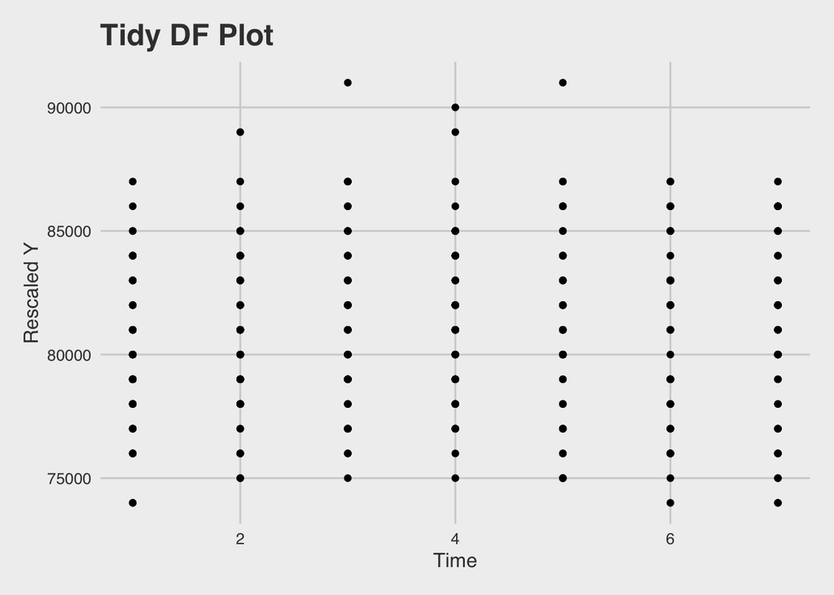

```r
# apply the 538 theme
# ----------
tidy_df %>%
  ggplot() +
  geom_point(aes(x = time, y = rescale_y)) +
  # apply the present parameters for the 538 theme
  ggthemes::theme_fivethirtyeight() +    # "::" allows you to call a function without loading it
  theme(axis.title = element_text()) +   # adjusts theme to allow for axis titles
  ggtitle("Tidy DF Plot") +              # title
  xlab("Time") +                         # x-axis label
  ylab("Rescaled Y")                     # y-axis label
```